# Bat Speed Model Markdown

Jason Hashimoto

2023-01-10

## Relationship between Bat Speed and Point of Interest (POI) metrics

Bat Speed Data Analysis on Driveline’s Open Biomechanics Project.

https://www.openbiomechanics.org/

By: Wasserberger KW, Brady AC, Besky DM, Jones BR, Boddy KJ. The OpenBiomechanics Project: The open source initiative for anonymized, elite-level athletic motion capture data. (2022).

This was completely inspired by Steve Schuster, Author of Growcasting. His twitter handle is @growcasting, and his twitter thread focused on using the POI metrics from Driveline Baseball on pitching and attempting to predict pitch velocity. Similarily, this analysis looked at POI metrics on hitting and attempted to predict bat speed.

The sample was mostly college guys, distribution of the sample and relevant information (POI Metrics) on the variables tested can be found here: https://github.com/drivelineresearch/openbiomechanics/tree/main/baseball_hitting

## Bat Speed Model

Removed the first 17 columns, which included mostly contact/bat metrics, which would flood the model with relationships already well understood (Ex: Bat Speed and Exit Velocity, Bat Speed and Attack Angle, etc). A simple Linear Regression model was then run with the remaining 110 variables available in the POI metrics dataframe. 677 observations were used in the mode, returning an R-squared of 0.613, which is a moderate correlation.

```r
#Bat Speed Model
all_metrics <- df %>% select(-c(1:17)) %>% as.data.frame()
formula <- as.formula(paste("bat_speed_mph_contact_x ~",
                            paste(setdiff(names(all_metrics),
                                  c("pelvis_fm_x", "pelvis_fm_y", "pelvis_fm_z", "pelvis_launchpos_x", "pelvis_launchpos_y", "pelvis_launchpos_z", "pelvis_angular_velocity_swing_max_x",
                                    "torso_angular_velocity_swing_max_x","torso_fm_x","torso_fm_y","torso_fm_z", "torso_launchpos_x", "torso_launchpos_y","torso_launchpos_z",
                                    "torso_pelvis_fm_x","torso_pelvis_launchpos_x","upper_arm_speed_mag_seq_max_x","upper_arm_speed_mag_swing_max_velo_x","bat_max_x","bat_min_x")),
                                  collapse = "+")))
model <- lm(formula, data = df)
tab_model(model, dv.labels = c("Bat Speed (mph)"))
```

|  | Bat Speed (mph) |  |  |
| --- | --- | --- | --- |
| Predictors | Estimates | CI | p |
| (Intercept) | -8.41 | -37.80 – 20.97 | 0.574 |
| pelvis angle fm x | -0.72 | -1.62 – 0.18 | 0.115 |
| pelvis angle fm y | 0.16 | -0.48 – 0.80 | 0.621 |
| pelvis angle fm z | 1.14 | 0.25 – 2.04 | **0.012** |
| pelvis angle fp x | -0.05 | -0.68 – 0.59 | 0.888 |
| pelvis angle fp y | 0.39 | -0.03 – 0.81 | 0.069 |
| pelvis angle fp z | -0.14 | -0.56 – 0.29 | 0.524 |
| pelvis angle hs x | 1.10 | 0.12 – 2.08 | **0.028** |
| pelvis angle hs y | -0.95 | -1.71 – -0.19 | **0.014** |
| pelvis angle hs z | -0.40 | -1.35 – 0.55 | 0.407 |
| torso angle fm x | 1.09 | 0.13 – 2.05 | **0.026** |
| torso angle fm y | 0.06 | -0.51 – 0.64 | 0.829 |
| torso angle fm z | -1.03 | -1.92 – -0.13 | **0.025** |
| torso angle fp x | -0.05 | -0.63 – 0.53 | 0.867 |
| torso angle fp y | -0.83 | -1.34 – -0.32 | **0.001** |
| torso angle fp z | 0.34 | -0.06 – 0.73 | 0.093 |
| torso angle hs x | -1.20 | -2.23 – -0.17 | **0.023** |
| torso angle hs y | 0.69 | -0.03 – 1.41 | 0.062 |
| torso angle hs z | 0.70 | -0.22 – 1.61 | 0.135 |
| upper arm speed mag max x | 0.00 | 0.00 – 0.01 | **0.014** |
| x factor fm x | 1.15 | 0.22 – 2.09 | **0.016** |
| x factor fm y | -0.27 | -0.95 – 0.41 | 0.432 |
| x factor fm z | 1.14 | 0.31 – 1.96 | **0.007** |
| x factor fp x | -0.24 | -0.80 – 0.32 | 0.396 |
| x factor fp y | 0.63 | 0.13 – 1.13 | **0.014** |
| x factor fp z | 0.16 | -0.26 – 0.58 | 0.456 |
| hand speed mag fm x | 0.02 | -0.04 – 0.08 | 0.445 |
| hand speed mag fp x | 0.00 | -0.00 – 0.01 | 0.058 |
| hand speed mag maxhss x | 0.00 | -0.00 – 0.00 | 0.565 |

[output cut: 64 more lines]

## VIP Importance

Using the VIP package, we can see the 10 predictors that had the most importance to the linear model.

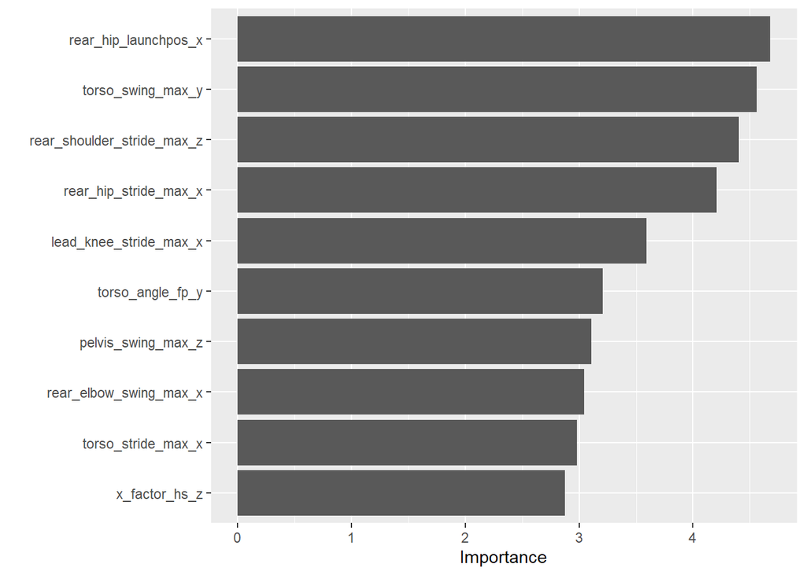

## XGBoost Models

Using 5 different XGBoost models, returning improved R-squared and RMSE values, as well as MAE and MSE.

```r
x <- model.matrix(formula, data = df)
y <- df$bat_speed_mph_contact_x

boost <- xgb.DMatrix(data = x, label = y)
boost_test <- xgb.DMatrix(data = x, label = y)

models <- list()
rmse <- c()
for (i in 1:5) {
  params <- list(eta = 0.1, max_depth = 3, subsample = 0.5, colsample_bytree = 0.5)
  result <- xgb.cv(data = boost, params = params, nrounds = 100, nfold = 5, early_stopping_rounds = 10, maximize = FALSE)
  model <- xgboost(data = boost, params = params, nrounds = 100, early_stopping_rounds = 10)
  models[[i]] <- model
  rmse[[i]] <- result$evaluation_log$train_rmse_mean
}

model_metrics <- data.frame(Model = character(), MSE = numeric(),
                            MAE = numeric(), RMSE = numeric(), R_square = numeric())
```

```r
for (i in 1:5) {
  pred_y <- predict(models[[i]], boost)
  mse <- mean((y - pred_y)^2)
  mae <- caret::MAE(y, pred_y)
  rmse <- caret::RMSE(y, pred_y)

  models_mean <- mean(y)
  residuals <- y - pred_y
  tss <- sum((y - models_mean)^2)
  rss <- sum(residuals^2)
  rsq <- 1 - (rss/tss)

  model_metrics <- rbind(model_metrics, data.frame(Model = paste("Model", i), MSE = mse,
                                                   MAE = mae, RMSE = rmse, R_square = rsq))
}

kable(model_metrics)
```

| Model | MSE | MAE | RMSE | R_square |
| --- | --- | --- | --- | --- |
| Model 1 | 2.751487 | 1.287226 | 1.658761 | 0.8800199 |
| Model 2 | 2.573884 | 1.262801 | 1.604333 | 0.8877643 |
| Model 3 | 2.602517 | 1.262506 | 1.613232 | 0.8865158 |
| Model 4 | 2.585028 | 1.259717 | 1.607802 | 0.8872784 |
| Model 5 | 2.569657 | 1.247454 | 1.603015 | 0.8879487 |

## Original vs. Predicted Bat Speed

Using this graph, we can see how well the Predicted Bat Speed Model faired against bat speed in the dataframe.

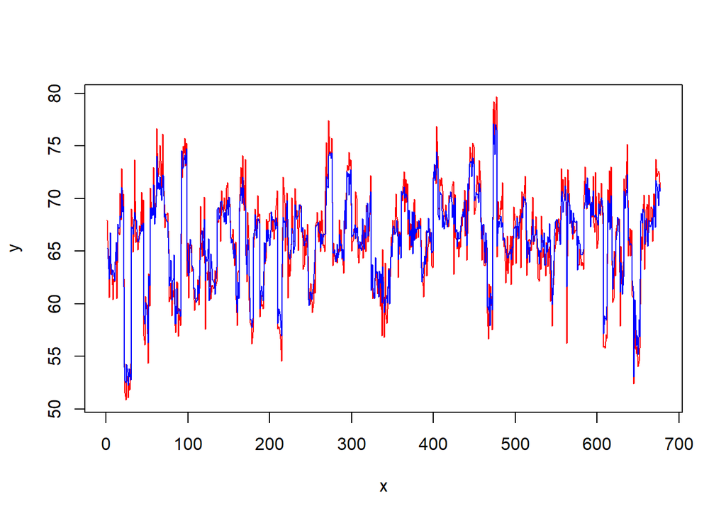

```r
#Plot to find out how the original test and predicted bat speed model compared

x = 1:length(y)
plot(x, y, col = "red", type = "l")
lines(x, pred_y, col = "blue", type = "l")
legend(x = 1, y = 38,  legend = c("original test_y", "predicted test_y"),
       col = c("red", "blue"), box.lty = 1, cex = 0.8, lty = c(1, 1))
```

## XGBoost Models VIP

For each of the 5 XGBoost models, we can use the VIP package to see which variables were the most important to predict bat speed. Most of these will have similar values, however there is a big difference between these predictors and the predictors that were highlighted in the original model.

```r
#XGBoost Models VIP
vip_scores_list <- list()

for (i in 1:length(models)) {
  vip_scores_list[[i]] <- vip(models[[i]])
  print(vip_scores_list[[i]])
}
```

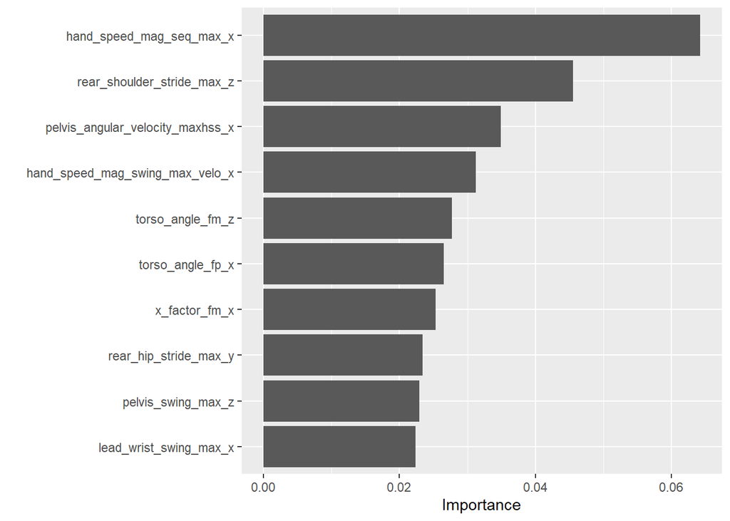

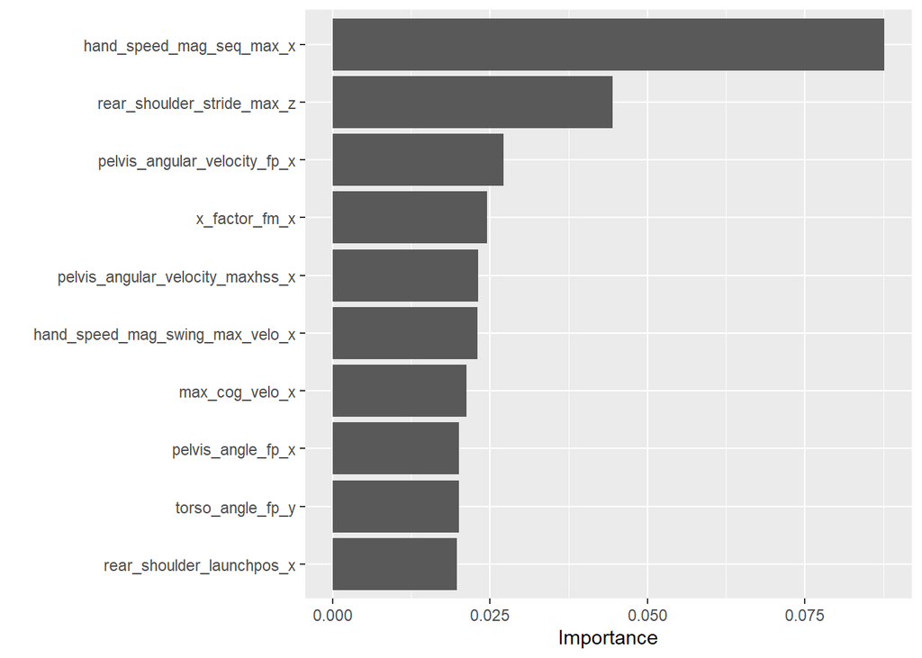

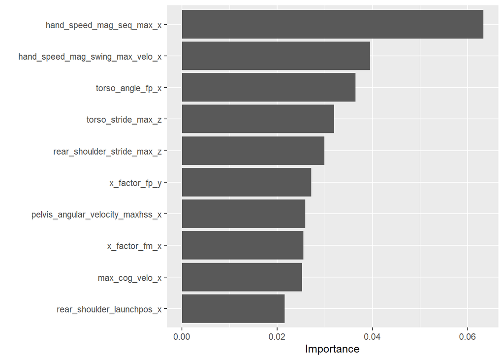

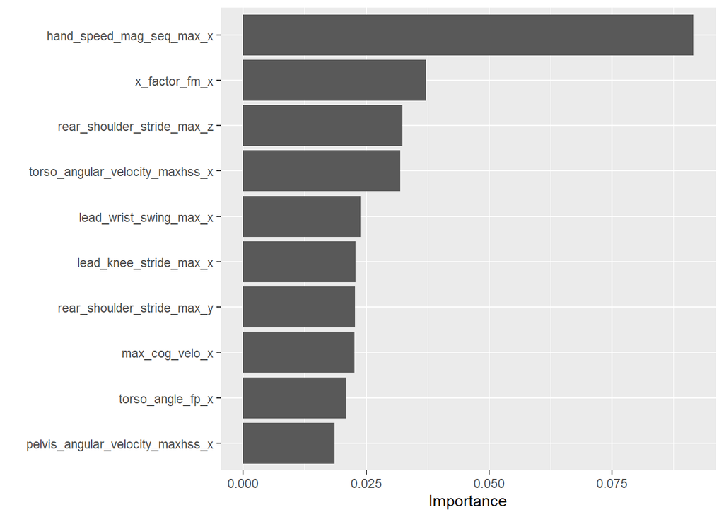

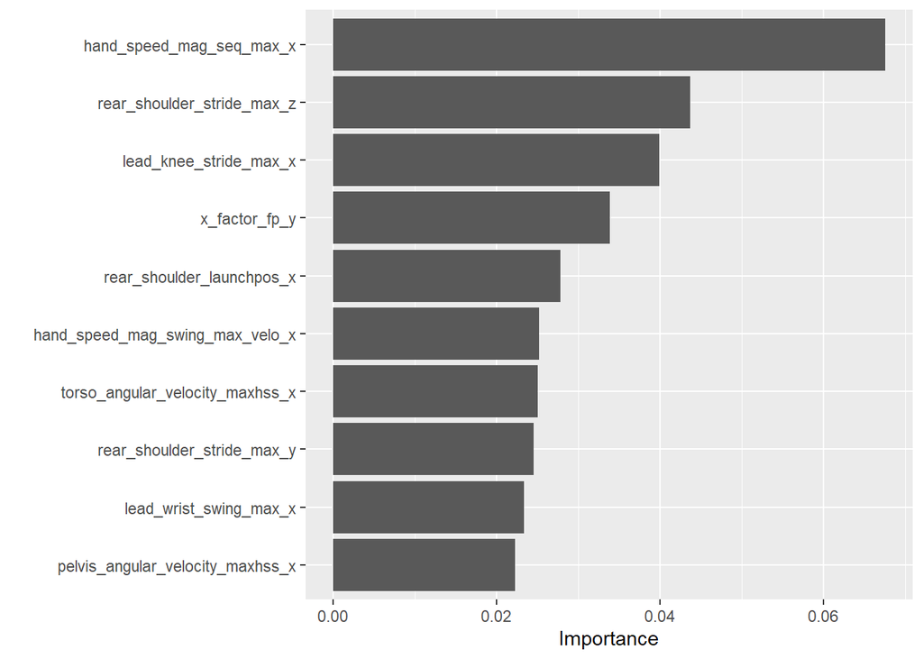